# PGM3

```python
import numpy as np
import pandas as pd
import matplotlib.pyplot as plt
from math import log, exp
from scipy.stats import multivariate_normal as mn
import time
```

```python
traindata=pd.read_table('/Users/adilrhiulam/Downloads/classification_data_HWK2/EMGaussiandata.txt',names=['x','y'],sep=' ')
testdata=pd.read_table('/Users/adilrhiulam/Downloads/classification_data_HWK2/EMGaussiantest.txt',names=['x','y'],sep=' ')
```

```python
train_data=traindata.values.tolist()
test_data=testdata.values.tolist()
```

1. Implement the recursions $\alpha$ et $\beta$ seen in class to compute $p(q_t\big| u_1, . . . , u_T )$ and $p(q_t, q_t+1\big|u_1, . . . , u_T )$.}

```python
def log_alpha_recursion(data,t,log_alpha_t_minus_1,A,log_PI,means,covariances):
    log_alpha_t = np.zeros(4)
    if (t==0):
        for k in range(4):
            log_alpha_t[k] = log_PI[k]+\
            log(mn.pdf(data[t],means[k],covariances[k]))
        return log_alpha_t
    maximum = np.max(log_alpha_t_minus_1)
    log_alpha_t_minus_1_ = np.array(log_alpha_t_minus_1) - maximum
    for k in range(4):
        somme = 0
        for i in range(4):
            somme+=exp(log_alpha_t_minus_1_[i])*A[k,i]
        log_alpha_t[k] = log(somme)+ maximum +log(mn.pdf(data[t],\
                                means[k],covariances[k]))
    return log_alpha_t

def log_beta_recursion(data,t,log_beta_t_plus_1,A,means,covariances):
    log_beta_t = np.zeros(4)
    T=len(data)
    if (t==T-1):
        log_beta_t = [0]*4
        return log_beta_t
    maximum = np.max(log_beta_t_plus_1)
    log_beta_t_plus_1_ = np.array(log_beta_t_plus_1) - maximum
    for k in range(4):
        somme = 0
        for i in range(4):
            somme+=exp(log_beta_t_plus_1_[i])*A[i,k]*mn.pdf(data[t+1],\
                                                           means[i],covariances[i])
        log_beta_t[k] = log(somme) + maximum
    return log_beta_t
```

Here I implemented log_alpha_recursion that takes in arguments the data, the time t (between 0 and T-1), log_alpha_t_minus_1 which is the previous log_alpha (at time t-1) and the paramaters log_PI, A, the means and covariances of the gaussians and it returns back the current log_alpha (at time t)

I implemented also log_beta_recursion that takes in arguments the data, the time t (between 0 and T-1), log_beta_t_plus_1 which is the next log_beta (at time t+1) and the paramaters A, the means and covariances of the gaussians and it returns back the current log_beta (at time t)

```python
def log_alpha(data,A,log_PI,means,covariances):
    T = len(data)
    log_alpha = np.zeros((T,4))
    log_alpha_t = []
    for t in range(T):
        log_alpha_t = log_alpha_recursion(data,t,log_alpha_t,A,log_PI,means,covariances)
        log_alpha[t] = log_alpha_t
    return log_alpha

def log_beta(data,A,means,covariances):
    T = len(data)
    log_beta = np.zeros((T,4))
    log_beta_t = []
    for t in range(T):
        log_beta_t = log_beta_recursion(data,T-1-t,log_beta_t,A,means,covariances)
        log_beta[T-1-t] = log_beta_t
    return log_beta
```

The functions log_alpha and log_beta return the values of log_alpha ald log_beta in a matrix form of shape (T,4) for all states and values of the random variables.

2. Using the same parameters for the means and covariance matrix of the 4 Gaussians as the ones obtained in the previous homework, taking a uniform initial probability distribution $\pi$ , and setting A to be the matrix with diagonal coefficients $A_{i,i}$ = $\frac{1}{2}$ and off-diagonal coefficients $A_{i,j}$ = $\frac{1}{6}$ for all (i, j) $\in$ $\{$1, . . . , 4$\}^2$, compute $\alpha_t$ and $\beta_t$ for all t on the test data and compute $p(q_t\big| u_1, . . . , u_T )$. Finally, represent $p(q_t\big| u_1, . . . , u_T )$ for each of the 4 states as a function of time for the 100 first data points in the file.

```python
means = np.array([[ 3.88666438, -3.88941241],\
       [-3.08450428, -3.53191272],\
       [ 4.03825229,  3.95482793],\
       [-2.19419536,  3.79119614]])

covariances = np.array([[[  1.04505209,0.10367199],\
        [  0.10367199,   1.0611463 ]],\
        [[  6.45912131,   6.04225818],\
        [  6.04225818,   6.07908052]],\
        [[  0.24966845,   0.05600596],\
        [  0.05600596,  10.87694132]],\
        [[  2.99227038,   0.05803126],\
        [  0.05803126,   3.50173754]]])
A = np.array([[0.5,1/6,1/6,1/6],\
           [1/6,0.5,1/6,1/6],\
           [1/6,1/6,0.5,1/6],\
           [1/6,1/6,1/6,0.5]])
log_PI = np.log([1/4,1/4,1/4,1/4])
```

Here we initialized the means and covariances with the parameters learned by the EM algorithm in the previous homework. The transition matrix and the log_PI are initialized as requested.

```python
log_alpha_ = log_alpha(test_data,A,log_PI,means,covariances)
log_beta_ = log_beta(test_data,A,means,covariances)
```

```python
log_alpha_
```

```
array([[  -39.22871054,    -3.95448341,  -161.61553728,   -16.61757526],
       [  -27.20670685,    -7.25644877,   -84.40804697,   -13.89674414],
       [  -17.05437252,   -31.34738608,   -12.53426413,   -21.89116934],
       ...,
       [-2426.41981513, -2398.95669138, -2518.74903242, -2410.09799691],
       [-2442.70514918, -2403.58096491, -2573.89416122, -2420.04572578],
       [-2442.21167888, -2406.95170386, -2561.00064799, -2421.16743694]])
```

```python
log_beta_
```

```
array([[-2404.09322534, -2402.99722085, -2404.09322535, -2404.08544257],
       [-2399.67525386, -2399.69656088, -2398.60532467, -2399.69604986],
       [-2394.42852435, -2394.42852435, -2394.42852435, -2393.32991206],
       ...,
       [   -9.09362889,    -7.99501665,    -9.09362889,    -9.09362875],
       [   -4.46934926,    -3.37073831,    -4.46934926,    -4.46934524],
       [    0.        ,     0.        ,     0.        ,     0.        ]])
```

```python
def log_smoothing(data,A,means,covariances,log_alpha_,log_beta_):
    T = len(data)
    log_product = log_alpha_ + log_beta_
    log_likelihood = log(np.sum(np.exp(log_alpha_[-1]-\
                            np.max(log_alpha_[-1]))))+np.max(log_alpha_[-1])
    log_smoothing = np.zeros((T,4))
    log_smoothing = log_product-log_likelihood
    return [log_smoothing,log_likelihood]
```

This function implemented the function returns the log values of the probabilities $p(q_t\big| u_1, . . . , u_T )$ in a matrix of shape (T,4) and the log_likelihood which is $p(u_1, . . . , u_T)$.

```python
log_smoothing_,log_likelihood = log_smoothing(test_data,A,means\
                                                 ,covariances,log_alpha_,log_beta_)
```

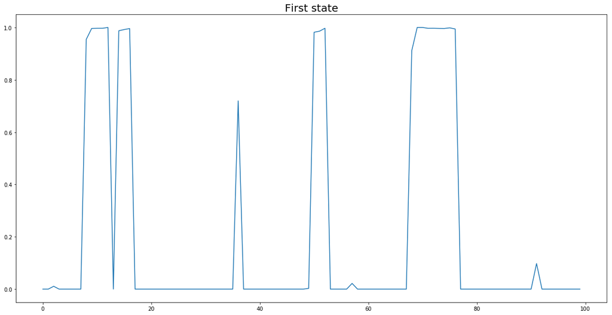

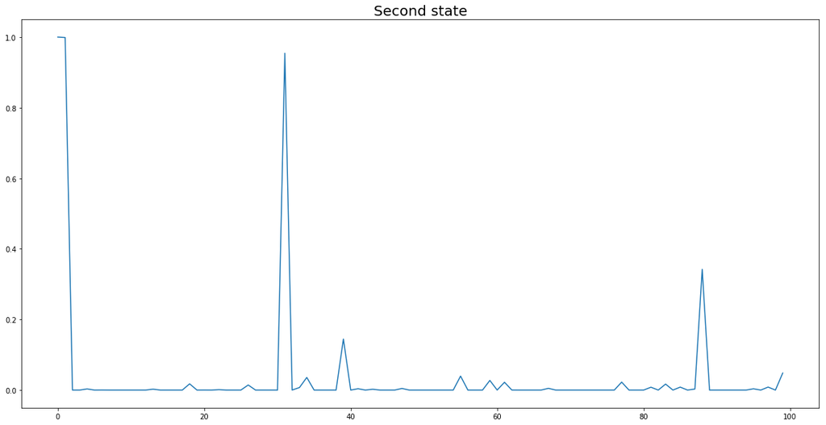

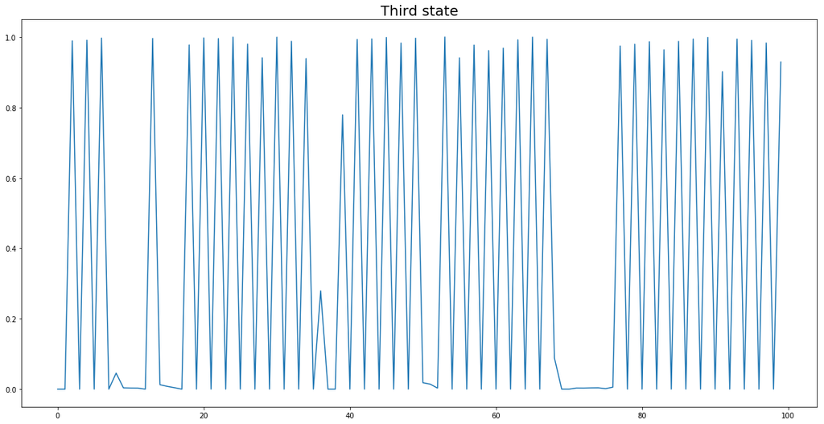

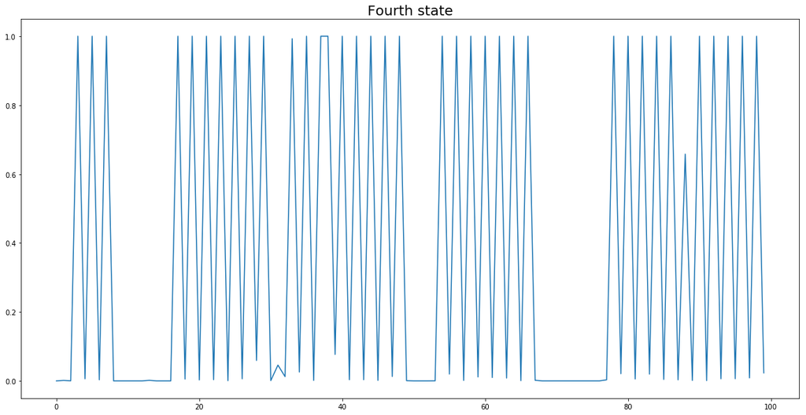

```python
point_to_plot = np.exp(log_smoothing_[0:100])
time = np.arange(100)
plt.figure(1,figsize=(20,10))
plt.plot(time,point_to_plot[:,0])
plt.title('First state',fontsize = 20)
plt.figure(2,figsize=(20,10))
plt.plot(time,point_to_plot[:,1])
plt.title('Second state',fontsize = 20)
plt.figure(3,figsize=(20,10))
plt.plot(time,point_to_plot[:,2])
plt.title('Third state',fontsize = 20)
plt.figure(4,figsize=(20,10))
plt.plot(time,point_to_plot[:,3])
plt.title('Fourth state',fontsize = 20)
plt.show()
```

4. Implement the EM algorithm to learn the parameters of the model ($\pi$, $A$, $\mu_k$, $\Sigma_k$, $k= 1...,4$). The means and covariances could be initialized with the ones obtained in the previous homework. Learn the model from the training data in “EMGaussienne.dat”.

```python
def log_joint_proba(data,A,means,covariances,log_alpha_,log_beta_,log_likelihood):
    T = len(data)
    log_joint_proba = np.zeros((T-1,4,4))
    for t in range(T-1):
        for i in range(4):
            for j in range(4):
                log_joint_proba[t,i,j] = log_alpha_[t,j] + log_beta_[t+1,i] + log(A[i,j])+\
                +log(mn.pdf(data[t+1],means[i],covariances[i])) - log_likelihood
    return log_joint_proba
```

This function $\textit{log_joint_proba}$ that calculate a tensor of shape (T-1,4,4) containing the log of the probabilities $p(q_t, q_{t+1}\big|u_1, . . . , u_T )$ that we will need in the EM algorithm.

```python
def intializationStepHMM(data):
    means = np.array([[ 3.80070948, -3.79729724],\
       [-2.03436695,  4.17258597],\
       [ 3.97793028,  3.77333115],\
       [-3.0619607 , -3.53454046]])

    covariances = np.array([[[  0.92127919,   0.05738079],\
        [  0.05738079,   1.86586056]],\
        [[  2.90442382,   0.20655764],\
        [  0.20655764,   2.75617077]],\
        [[  0.21035665,   0.29045072],\
        [  0.29045072,  12.23996355]],\
        [[  6.2414092 ,   6.05017473],\
        [  6.05017473,   6.18245537]]])
    A = np.array([[0.5,1/6,1/6,1/6],\
           [1/6,0.5,1/6,1/6],\
           [1/6,1/6,0.5,1/6],\
           [1/6,1/6,1/6,0.5]])
    log_PI = np.log([1/4,1/4,1/4,1/4])
    return [means,covariances,A,log_PI]

def stepE_HMM(data,means,covariances,A,log_PI):
    log_alpha_ = log_alpha(data,A,log_PI,means,covariances)
    log_beta_ = log_beta(data,A,means,covariances)
    log_smoothing_,log_likelihood = log_smoothing(data,A,means\
                                                 ,covariances,log_alpha_,log_beta_)
    log_joint_proba_ = log_joint_proba(data,A,means\
                                      ,covariances,log_alpha_,log_beta_,log_likelihood)
    return [log_smoothing_,log_joint_proba_,log_likelihood]

def stepM_HMM(data,log_smoothing_,log_joint_proba_):
    T = len(data)
    log_PI = log_smoothing_[0]
    A = (np.sum(np.exp(log_joint_proba_),axis=0).T/np.sum(np.exp(log_smoothing_[:T-1]),axis=0)).T
    x = np.zeros((T,4,2))
    y = np.sum(np.exp(log_smoothing_),axis=0)
    for t in range(T):
        for i in range(4):
            x[t,i] = np.exp(log_smoothing_)[t,i]*np.array(data[t])
    means = (np.sum(x,axis=0).T/y).T
    covariances = np.array([np.sum([np.exp(log_smoothing_)[t,i]*\
                                    np.dot(np.array([data[t]-means[i]]).T,[data[t]-means[i]])\
                                    for t in range(T)],axis=0)/y[i] for i in range(4)])
    return [log_PI,A,means,covariances]

def algorithmEM_HMM(data):
    [means,covariances,A,log_PI] = intializationStepHMM(data)
    [log_smoothing_,log_joint_proba_,log_likelihood] = stepE_HMM(data,means,covariances,A,log_PI)
    log_likelihood_history = [log_likelihood]
    log_llh2 = log_likelihood+2
    while(abs(log_likelihood-log_llh2)>0.0001):
        log_llh2 = log_likelihood
        [log_PI,A,means,covariances] = stepM_HMM(data,log_smoothing_,log_joint_proba_)
        [log_smoothing_,log_joint_proba_,log_likelihood] = stepE_HMM(data,means,covariances,A,log_PI)
        log_likelihood_history.append(log_likelihood)
    return [log_PI,A,means,covariances,log_likelihood_history]
```

```python
log_PI_train,A_train,means_train,covariances_train,log_likelihood_history_train\
= algorithmEM_HMM(train_data)
```

```python
print('log(PI) = ',log_PI_train)
print('A = ', A_train)
print('means = ',means_train)
print('covariances = ', covariances_train)
```

```
log(PI) =  [ -5.50195669e+01  -2.83764504e+01  -1.48889756e+02  -2.95585778e-12]
A =  [[ 0.87860557  0.06792749  0.01799263  0.03547432]
 [ 0.02705241  0.01576445  0.94904963  0.00813356]
 [ 0.031911    0.85984905  0.02250631  0.08573364]
 [ 0.01939464  0.05234451  0.02758432  0.90067649]]
means =  [[ 3.78915942 -3.97479781]
 [-1.95013568  4.19401969]
 [ 3.99447762  3.6336008 ]
 [-2.96884882 -3.44596339]]
covariances =  [[[  0.94419417   0.06121408]
  [  0.06121408   1.55399898]]

 [[  3.28362594   0.3046625 ]
  [  0.3046625    2.83129284]]

 [[  0.19769952   0.25884686]
  [  0.25884686  12.34090692]]

 [[  6.80922442   6.58541086]
  [  6.58541086   6.6864791 ]]]
```

```python
log_likelihood_history_train
```

```
[-2299.8921568273727,
 -1912.5056563866569,
 -1898.6083858020449,
 -1897.0229660793962,
 -1896.8223634373323,
 -1896.7935068746433,
 -1896.7893755982857,
 -1896.788796228017,
 -1896.7887156776389]
```

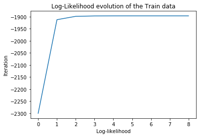

```python
plt.plot(log_likelihood_history_train)
plt.title('Log-Likelihood evolution of the Train data')
plt.xlabel('Log-likelihood')
plt.ylabel('Iteration')
plt.show()
```

```python
log_PI_test,A_test,means_test,covariances_test,log_likelihood_history_test \
= algorithmEM_HMM(test_data)
```

```python
print('log(PI) = ',log_PI_test)
print('A = ', A_test)
print('means = ',means_test)
print('covariances = ', covariances_test)
```

```
log(PI) =  [ -3.47236350e+02  -1.50862053e+02  -1.42445867e+03  -7.27595761e-12]
A =  [[ 0.86314319  0.01636783  0.07264319  0.04784578]
 [ 0.02551796  0.01904228  0.93994906  0.0154907 ]
 [ 0.03870837  0.93924103  0.01234617  0.00970443]
 [ 0.05349161  0.0140808   0.05346819  0.87895939]]
means =  [[ 3.89948967 -3.91028597]
 [-2.16956621  3.79378548]
 [ 4.0362931   3.8536663 ]
 [-3.15176532 -3.59979688]]
covariances =  [[[  1.04681934   0.16517703]
  [  0.16517703   1.16062877]]

 [[  3.09024275   0.04353053]
  [  0.04353053   3.43933263]]

 [[  0.26041219   0.09502294]
  [  0.09502294  11.3693293 ]]

 [[  5.99783521   5.60401908]
  [  5.60401908   5.65217157]]]
```

```python
log_likelihood_history_test
```

```
[-2424.1431646247784,
 -1937.95481442242,
 -1919.0196341456467,
 -1916.83026637586,
 -1916.4807458429805,
 -1916.4176529496224,
 -1916.4068890402159,
 -1916.4050458098752,
 -1916.4047265487923,
 -1916.4046709109989]
```

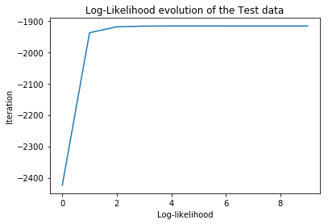

```python
plt.plot(log_likelihood_history_test)
plt.title('Log-Likelihood evolution of the Test data')
plt.xlabel('Log-likelihood')
plt.ylabel('Iteration')
plt.show()
```

8. Implement Viterbi decoding. For the set of parameters learned with the EM algorithm, compute the most likely sequence of states with the Viterbi algorithm and represent the data in 2D with the cluster centers and with markers of different colors for the data points belonging to different classes.

```python
def log_viterbi_recursion(data,t,viterbi_t_minus_1,A,log_PI,means,covariances):
    log_viterbi_t = np.zeros(4)
    if (t==0):
        for k in range(4):
            log_viterbi_t[k] = log_PI[k]+\
            log(mn.pdf(data[t],means[k],covariances[k]))
        return log_viterbi_t,[]
    else:
        quantity = np.array([list(viterbi_t_minus_1)]*4)+np.log(A)
        maximum = np.max(quantity,axis=1)
        argmax_t = np.argmax(quantity,axis=1)
        for k in range(4):
            log_viterbi_t[k] = log(mn.pdf(data[t],means[k],covariances[k]))+\
            maximum[k]
        return log_viterbi_t,argmax_t
```

I implemented first the function \textit{log\_viterbi\_recursion} that takes in arguments the data, the time t, the log of the previous value of the Viterbi algorithm (at time t-1), the transition matrix A, the log of the initial probability distribution log\_PI and finally the means, covariances of the Gaussian emission probabilities, it returns back the log of the current value of Viterbi Algorithm (at time t) and also the states of the previous value of the Viterbi algorithm that correspond to the maxima for each state of the 4 states of the $t^{th}$ value of Viterbi Algorithm returned.

```python
def log_viterbi(data,A,log_PI,means,covariances):
    T = len(data)
    log_viterbi = np.zeros((T,4))
    maximal_states = np.zeros((T-1,4),dtype=int)
    log_viterbi_t = []
    for t in range(T):
        log_viterbi_t,argmax_t = log_viterbi_recursion(data,t,log_viterbi_t,A,\
                                                       log_PI,means,covariances)
        log_viterbi[t] = log_viterbi_t
        if (t!=0):
            maximal_states[t-1,:] = argmax_t
    return log_viterbi,maximal_states

#we are looking in the function below for the most probable path
#for the k-th value of the state t

T = len(train_data)
def most_likely_sequence(maximal_states, t=T):
    most_probable_path = np.zeros((4,t),dtype=int)
    for k in range(4):
        most_probable_path[k,t-1] = k
        maximal_states = maximal_states[0:t-1,:]
        back_track = k
        for i in range(t-1):
            back_track = maximal_states[t-2-i,back_track]
            most_probable_path[k,t-2-i] = back_track
    return most_probable_path
```